# BCB Report

CMRI Biostatistics and Computational Biology Core

Author

Analyst

Published

October 29, 2026

# Load Libraries

```r
#install cmribio from github
#library(pak)
#pak::pkg_install("jmvarberg/cmribio")
library(cmribio)
library(tidyverse)
library(cowplot)
library(ggsci)
library(ggpubr)
library(rstatix)
library(data.table)
library(DT)

#download logo to use for example
logo <- "https://raw.githubusercontent.com/jmvarberg/cmribio/main/man/figures/logo.png"
dest <- "logo.png"

download.file(logo, dest)
```

## Background and Objectives

**Bold** any important information, and *italicize* any key terms. Use bullet points to list items.

Embed a locally-saved image like this:

[figure not shown]

Include call-outs (notes, warnings, info etc) to users like this:

**Note**

Note that there are five types of callouts, including: `note`, `warning`, `important`, `tip`, and `caution`.

**TipTip with Title**

This is an example of a callout with a title.

**CautionExpand To Learn About Collapse**

This is an example of a ‘folded’ caution callout that can be expanded by the user. You can use `collapse="true"` to collapse it by default or `collapse="false"` to make a collapsible callout that is expanded by default.

## Results

### Table 1: Summary of Study Design and Cohort

Example of how to use `gtsummary()` to create Table 1 and save it out as Excel file.

```r
table1 <- mtcars |>
  gtsummary::tbl_summary(
    by = cyl) |>
  gtsummary::add_p()

#print table 1
if (knitr::is_html_output()) {
  table1
}
```

| **Characteristic** | **4** N = 11<sup>1</sup> | **6** N = 7<sup>1</sup> | **8** N = 14<sup>1</sup> | **p-value**<sup>2</sup> |
| --- | --- | --- | --- | --- |
| mpg | 26.0 (22.8, 30.4) | 19.7 (18.1, 21.0) | 15.2 (14.3, 16.4) | <0.001 |
| disp | 108 (79, 121) | 168 (160, 225) | 351 (301, 400) | <0.001 |
| hp | 91 (65, 97) | 110 (110, 123) | 193 (175, 245) | <0.001 |
| drat | 4.08 (3.77, 4.22) | 3.90 (3.08, 3.92) | 3.12 (3.07, 3.23) | <0.001 |
| wt | 2.20 (1.84, 2.78) | 3.22 (2.77, 3.44) | 3.76 (3.52, 4.07) | <0.001 |
| qsec | 18.90 (18.52, 20.00) | 18.30 (16.46, 19.44) | 17.18 (15.84, 17.60) | 0.006 |
| vs | 10 (91%) | 4 (57%) | 0 (0%) | <0.001 |
| am | 8 (73%) | 3 (43%) | 2 (14%) | 0.009 |
| gear |  |  |  | <0.001 |
| 3 | 1 (9.1%) | 2 (29%) | 12 (86%) |  |
| 4 | 8 (73%) | 4 (57%) | 0 (0%) |  |
| 5 | 2 (18%) | 1 (14%) | 2 (14%) |  |
| carb |  |  |  | <0.001 |
| 1 | 5 (45%) | 2 (29%) | 0 (0%) |  |
| 2 | 6 (55%) | 0 (0%) | 4 (29%) |  |
| 3 | 0 (0%) | 0 (0%) | 3 (21%) |  |
| 4 | 0 (0%) | 4 (57%) | 6 (43%) |  |
| 6 | 0 (0%) | 1 (14%) | 0 (0%) |  |
| 8 | 0 (0%) | 0 (0%) | 1 (7.1%) |  |

<sup>1</sup> Median (Q1, Q3); n (%)  
<sup>2</sup> Kruskal-Wallis rank sum test; Fisher’s exact test

```r
#export to Excel file
gtsummary::as_hux_xlsx(table1, file = "./output_table1.xlsx")
```

### Tables and Graphs

Include separate sections and chunks used to generate results tables and plots during the analysis.

#### Static and Interactive Tables

Here are simple examples of how to make static or interactive tables. See source code for examples for how to optionally have Quarto only execute the chunks with interactive tables/plots if being rendered to HTML. This will prevent errors with interactive outputs when rendering to Word/.docx files.

```r
#static table output
mtcars |>
  knitr::kable()
```

|  | mpg | cyl | disp | hp | drat | wt | qsec | vs | am | gear | carb |
| --- | --- | --- | --- | --- | --- | --- | --- | --- | --- | --- | --- |
| Mazda RX4 | 21.0 | 6 | 160.0 | 110 | 3.90 | 2.620 | 16.46 | 0 | 1 | 4 | 4 |
| Mazda RX4 Wag | 21.0 | 6 | 160.0 | 110 | 3.90 | 2.875 | 17.02 | 0 | 1 | 4 | 4 |
| Datsun 710 | 22.8 | 4 | 108.0 | 93 | 3.85 | 2.320 | 18.61 | 1 | 1 | 4 | 1 |
| Hornet 4 Drive | 21.4 | 6 | 258.0 | 110 | 3.08 | 3.215 | 19.44 | 1 | 0 | 3 | 1 |
| Hornet Sportabout | 18.7 | 8 | 360.0 | 175 | 3.15 | 3.440 | 17.02 | 0 | 0 | 3 | 2 |
| Valiant | 18.1 | 6 | 225.0 | 105 | 2.76 | 3.460 | 20.22 | 1 | 0 | 3 | 1 |
| Duster 360 | 14.3 | 8 | 360.0 | 245 | 3.21 | 3.570 | 15.84 | 0 | 0 | 3 | 4 |
| Merc 240D | 24.4 | 4 | 146.7 | 62 | 3.69 | 3.190 | 20.00 | 1 | 0 | 4 | 2 |
| Merc 230 | 22.8 | 4 | 140.8 | 95 | 3.92 | 3.150 | 22.90 | 1 | 0 | 4 | 2 |
| Merc 280 | 19.2 | 6 | 167.6 | 123 | 3.92 | 3.440 | 18.30 | 1 | 0 | 4 | 4 |
| Merc 280C | 17.8 | 6 | 167.6 | 123 | 3.92 | 3.440 | 18.90 | 1 | 0 | 4 | 4 |
| Merc 450SE | 16.4 | 8 | 275.8 | 180 | 3.07 | 4.070 | 17.40 | 0 | 0 | 3 | 3 |
| Merc 450SL | 17.3 | 8 | 275.8 | 180 | 3.07 | 3.730 | 17.60 | 0 | 0 | 3 | 3 |
| Merc 450SLC | 15.2 | 8 | 275.8 | 180 | 3.07 | 3.780 | 18.00 | 0 | 0 | 3 | 3 |
| Cadillac Fleetwood | 10.4 | 8 | 472.0 | 205 | 2.93 | 5.250 | 17.98 | 0 | 0 | 3 | 4 |
| Lincoln Continental | 10.4 | 8 | 460.0 | 215 | 3.00 | 5.424 | 17.82 | 0 | 0 | 3 | 4 |
| Chrysler Imperial | 14.7 | 8 | 440.0 | 230 | 3.23 | 5.345 | 17.42 | 0 | 0 | 3 | 4 |
| Fiat 128 | 32.4 | 4 | 78.7 | 66 | 4.08 | 2.200 | 19.47 | 1 | 1 | 4 | 1 |
| Honda Civic | 30.4 | 4 | 75.7 | 52 | 4.93 | 1.615 | 18.52 | 1 | 1 | 4 | 2 |
| Toyota Corolla | 33.9 | 4 | 71.1 | 65 | 4.22 | 1.835 | 19.90 | 1 | 1 | 4 | 1 |
| Toyota Corona | 21.5 | 4 | 120.1 | 97 | 3.70 | 2.465 | 20.01 | 1 | 0 | 3 | 1 |
| Dodge Challenger | 15.5 | 8 | 318.0 | 150 | 2.76 | 3.520 | 16.87 | 0 | 0 | 3 | 2 |
| AMC Javelin | 15.2 | 8 | 304.0 | 150 | 3.15 | 3.435 | 17.30 | 0 | 0 | 3 | 2 |
| Camaro Z28 | 13.3 | 8 | 350.0 | 245 | 3.73 | 3.840 | 15.41 | 0 | 0 | 3 | 4 |
| Pontiac Firebird | 19.2 | 8 | 400.0 | 175 | 3.08 | 3.845 | 17.05 | 0 | 0 | 3 | 2 |
| Fiat X1-9 | 27.3 | 4 | 79.0 | 66 | 4.08 | 1.935 | 18.90 | 1 | 1 | 4 | 1 |
| Porsche 914-2 | 26.0 | 4 | 120.3 | 91 | 4.43 | 2.140 | 16.70 | 0 | 1 | 5 | 2 |
| Lotus Europa | 30.4 | 4 | 95.1 | 113 | 3.77 | 1.513 | 16.90 | 1 | 1 | 5 | 2 |
| Ford Pantera L | 15.8 | 8 | 351.0 | 264 | 4.22 | 3.170 | 14.50 | 0 | 1 | 5 | 4 |
| Ferrari Dino | 19.7 | 6 | 145.0 | 175 | 3.62 | 2.770 | 15.50 | 0 | 1 | 5 | 6 |
| Maserati Bora | 15.0 | 8 | 301.0 | 335 | 3.54 | 3.570 | 14.60 | 0 | 1 | 5 | 8 |
| Volvo 142E | 21.4 | 4 | 121.0 | 109 | 4.11 | 2.780 | 18.60 | 1 | 1 | 4 | 2 |

```r
#interactive table output
if (knitr::is_html_output()) {
  mtcars |>
    cmribio::cmri_datatable()
}
```

|  | mpg | cyl | disp | hp | drat | wt | qsec | vs | am | gear | carb |
| --- | --- | --- | --- | --- | --- | --- | --- | --- | --- | --- | --- |
| Mazda RX4 | 21 | 6 | 160 | 110 | 3.9 | 2.62 | 16.46 | 0 | 1 | 4 | 4 |
| Mazda RX4 Wag | 21 | 6 | 160 | 110 | 3.9 | 2.88 | 17.02 | 0 | 1 | 4 | 4 |
| Datsun 710 | 22.8 | 4 | 108 | 93 | 3.85 | 2.32 | 18.61 | 1 | 1 | 4 | 1 |
| Hornet 4 Drive | 21.4 | 6 | 258 | 110 | 3.08 | 3.21 | 19.44 | 1 | 0 | 3 | 1 |
| Hornet Sportabout | 18.7 | 8 | 360 | 175 | 3.15 | 3.44 | 17.02 | 0 | 0 | 3 | 2 |
| Valiant | 18.1 | 6 | 225 | 105 | 2.76 | 3.46 | 20.22 | 1 | 0 | 3 | 1 |
| Duster 360 | 14.3 | 8 | 360 | 245 | 3.21 | 3.57 | 15.84 | 0 | 0 | 3 | 4 |
| Merc 240D | 24.4 | 4 | 146.7 | 62 | 3.69 | 3.19 | 20 | 1 | 0 | 4 | 2 |
| Merc 230 | 22.8 | 4 | 140.8 | 95 | 3.92 | 3.15 | 22.9 | 1 | 0 | 4 | 2 |
| Merc 280 | 19.2 | 6 | 167.6 | 123 | 3.92 | 3.44 | 18.3 | 1 | 0 | 4 | 4 |

[output cut: 22 more lines]

#### Static and Interactive Plots

Here are basic examples of using static and interactive plots.

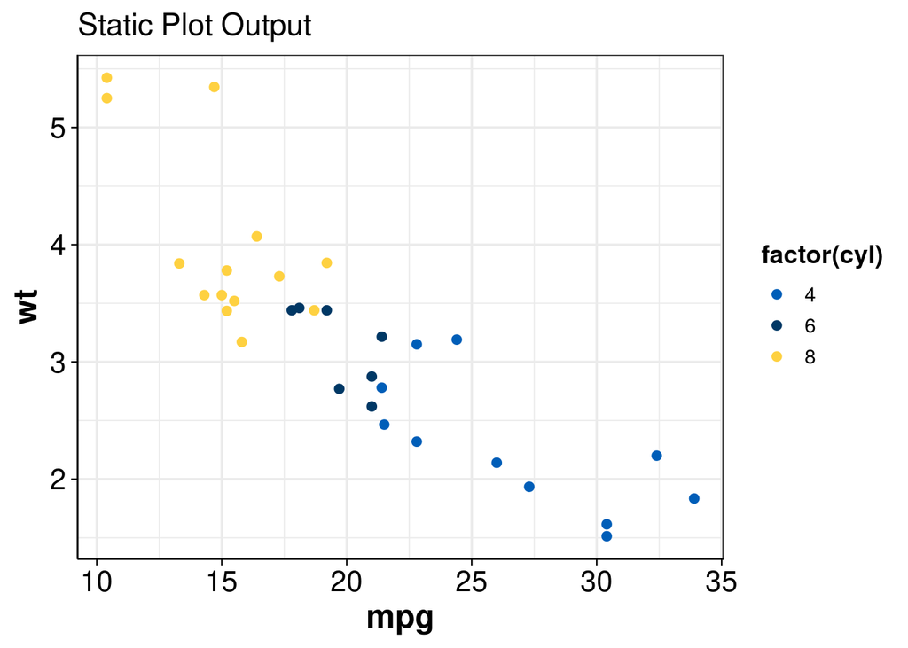

```r
p <- ggplot(mtcars, aes(x = mpg, y = wt, color = factor(cyl), text1 = disp, text2=drat, text3 = qsec, text4 = gear, text5 = carb)) +
  geom_point() +
  scale_color_bcb() +
  theme_bcb(base_theme = "bw")

#static plot
p + ggtitle("Static Plot Output")
```

```r
library(plotly)
#interactive plot
pp <- p + ggtitle("ggplotly Interactive Output")
if (knitr::is_html_output()) {
  ggplotly(pp)
}
```

[interactive chart not shown]

Figure 2: Interactive plot

You can also modify the size of the plot generated by each chunk like this:

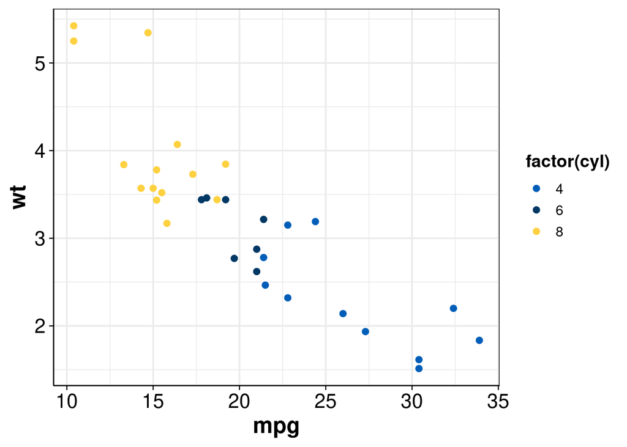

```r
#default size
p
```

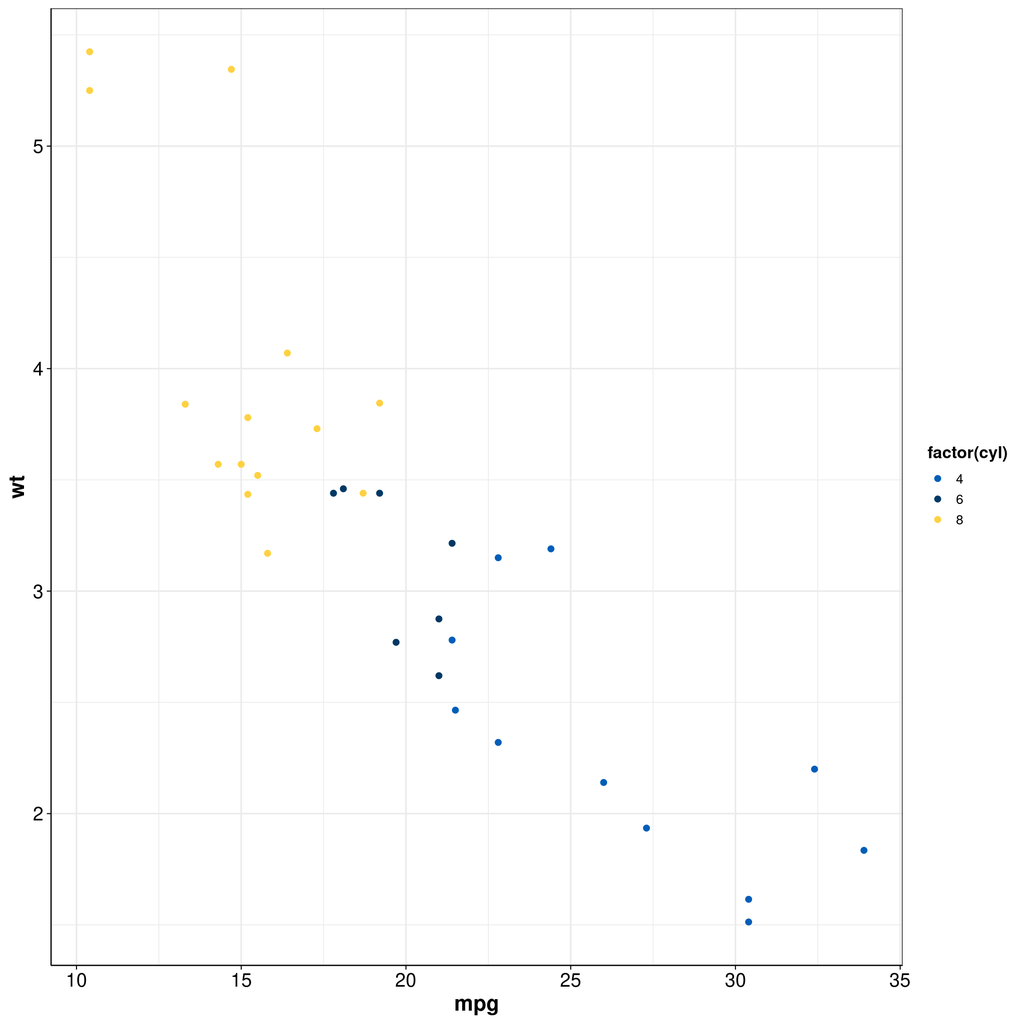

```r
p
```

### Using Tabs

It can be helpful to use tabs to organize reports with multiple outputs/plots/tables. Here we show an example of how to use this feature.

**Plot**

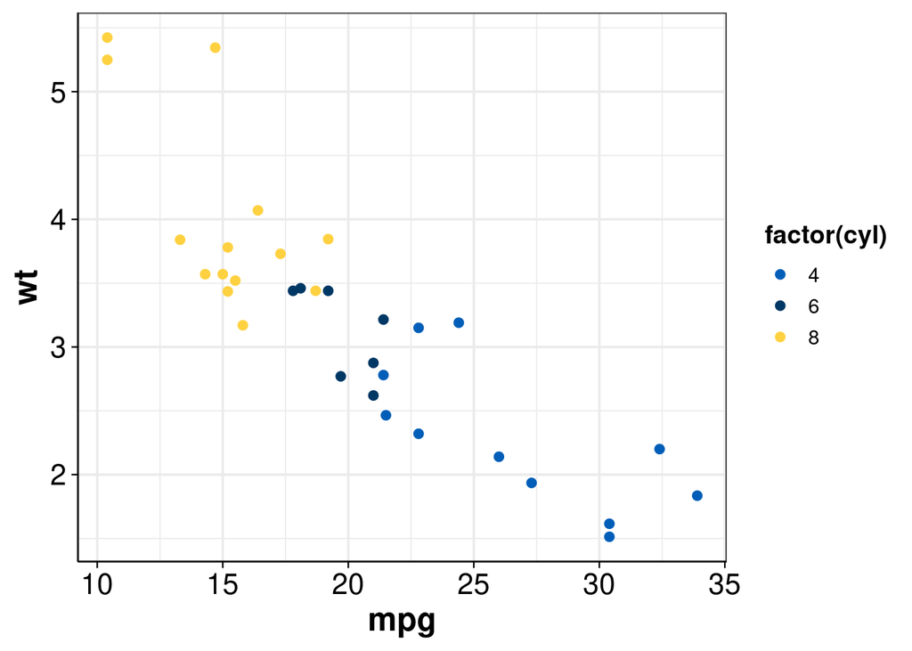

```r
p
```

**Table**

```r
if (knitr::is_html_output()) {
  mtcars |> cmribio::cmri_datatable()
}
```

|  | mpg | cyl | disp | hp | drat | wt | qsec | vs | am | gear | carb |
| --- | --- | --- | --- | --- | --- | --- | --- | --- | --- | --- | --- |
| Mazda RX4 | 21 | 6 | 160 | 110 | 3.9 | 2.62 | 16.46 | 0 | 1 | 4 | 4 |
| Mazda RX4 Wag | 21 | 6 | 160 | 110 | 3.9 | 2.88 | 17.02 | 0 | 1 | 4 | 4 |
| Datsun 710 | 22.8 | 4 | 108 | 93 | 3.85 | 2.32 | 18.61 | 1 | 1 | 4 | 1 |
| Hornet 4 Drive | 21.4 | 6 | 258 | 110 | 3.08 | 3.21 | 19.44 | 1 | 0 | 3 | 1 |
| Hornet Sportabout | 18.7 | 8 | 360 | 175 | 3.15 | 3.44 | 17.02 | 0 | 0 | 3 | 2 |
| Valiant | 18.1 | 6 | 225 | 105 | 2.76 | 3.46 | 20.22 | 1 | 0 | 3 | 1 |
| Duster 360 | 14.3 | 8 | 360 | 245 | 3.21 | 3.57 | 15.84 | 0 | 0 | 3 | 4 |
| Merc 240D | 24.4 | 4 | 146.7 | 62 | 3.69 | 3.19 | 20 | 1 | 0 | 4 | 2 |
| Merc 230 | 22.8 | 4 | 140.8 | 95 | 3.92 | 3.15 | 22.9 | 1 | 0 | 4 | 2 |
| Merc 280 | 19.2 | 6 | 167.6 | 123 | 3.92 | 3.44 | 18.3 | 1 | 0 | 4 | 4 |

[output cut: 22 more lines]

### Embedded files

The function `xfun::embed_file()` and related functions can be used to directly embed results files, like CSVs or Excel files, into the document. It will then be self-contained, so anyone with the report can download the embedded file.

```r
#showing simple example

#create results data frame
results <- mtcars

#save results to the project results directory
write.csv(mtcars, "./results/mtcars.csv", row.names = F)

#also embed a copy of the results in the HTML report for quick access and sharing with collaborators
xfun::embed_file("./results/mtcars.csv", "./results/mtcars.csv", "Results - mtcars.csv")
```

## Conclusions

Link out to any relevant external websites using [link](https://www.google.com/).

## Session Info

```r
#install.packages("sessioninfo")
library(sessioninfo)
```